# Analisi del testo di Simpson e Griffin

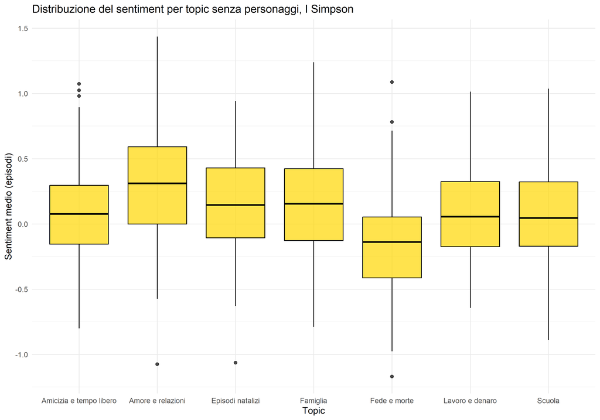

```r
ggplot(sentiment_lda_imdb_s, aes(x = factor(titolo_topic), y = sentiment)) +
  geom_boxplot(fill = "#FFD700", color = "black", alpha = 0.7) +
  labs(
    title = "Distribuzione del sentiment per topic senza personaggi, I Simpson",
    x = "Topic",
    y = "Sentiment medio (episodi)"
  ) +
  theme_minimal()
```

Anche nell’analisi con i personaggi, si mantengono le stesse caratteristiche viste in precedenza.

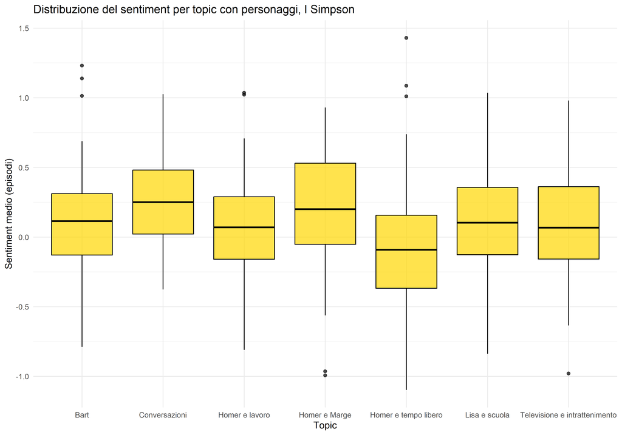

```r
ggplot(sentiment_lda_imdb_s2, aes(x = factor(titolo_topic), y = sentiment)) +
  geom_boxplot(fill = "#FFD700", color = "black", alpha = 0.7) +
  labs(
    title = "Distribuzione del sentiment per topic con personaggi, I Simpson",
    x = "Topic",
    y = "Sentiment medio (episodi)"
  ) +
  theme_minimal()
```

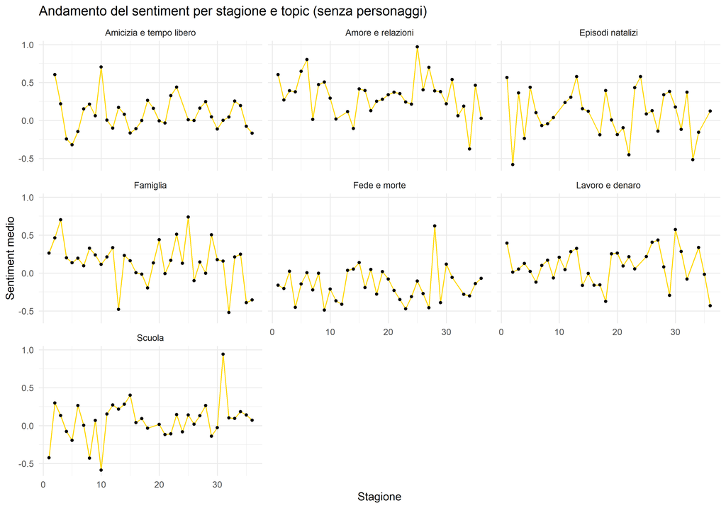

```r
sentiment_lda_imdb_s %>%
  group_by(titolo_topic, stagione) %>%
  summarise(sentiment_medio = mean(sentiment), .groups = "drop") %>%
  ggplot(aes(x = stagione, y = sentiment_medio)) +
  geom_line(color = "#FFD700", size = 0.5) +
  geom_point(size = 1) +
  facet_wrap(~ titolo_topic, ncol = 3) +
  labs(
    title = "Andamento del sentiment per stagione e topic (senza personaggi)",
    x = "Stagione",
    y = "Sentiment medio"
  ) +
  theme_minimal()
```

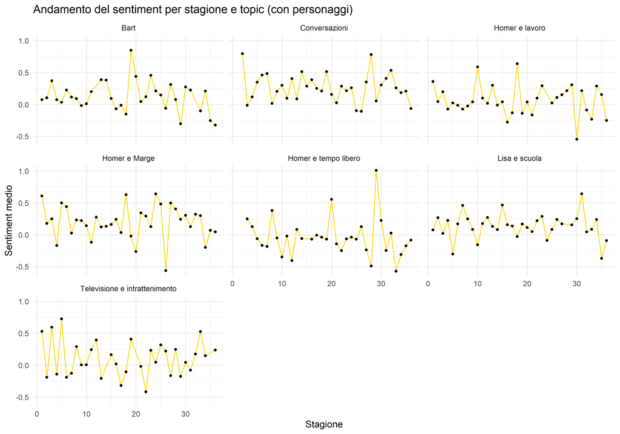

```r
sentiment_lda_imdb_s2 %>%
  group_by(titolo_topic, stagione) %>%
  summarise(sentiment_medio = mean(sentiment), .groups = "drop") %>%
  ggplot(aes(x = stagione, y = sentiment_medio)) +
  geom_line(color = "#FFD700", size = 0.5) +
  geom_point(size = 1) +
  facet_wrap(~ titolo_topic, ncol = 3, labeller = labeller(topic = titoli_topic_s2)) +
  labs(
    title = "Andamento del sentiment per stagione e topic (con personaggi)",
    x = "Stagione",
    y = "Sentiment medio"
  ) +
  theme_minimal()
```

Si ripete la stessa analisi per *I Griffin*.

I *boxplot* del *sentiment* per *topic* sembrano mantenere una mediana attorno allo 0, con un valore leggermente superiore per il *topic* Relazioni e inferiore per Violenza, riflettendo il forte utilizzo di parole scurrili e dalla caratterizzazione negativa nella serie. Si noti inoltre come per questa serie la variabilità del *sentiment* sia superiore, soprattutto verso valori negativi, rispetto a *I Simpson*, riflettendo una narrazione caratterizzata da toni più crudi e contenuti per un pubblico maturo. La serie adotta deliberatamente un approccio narrativo più diretto e provocatorio della precedente.

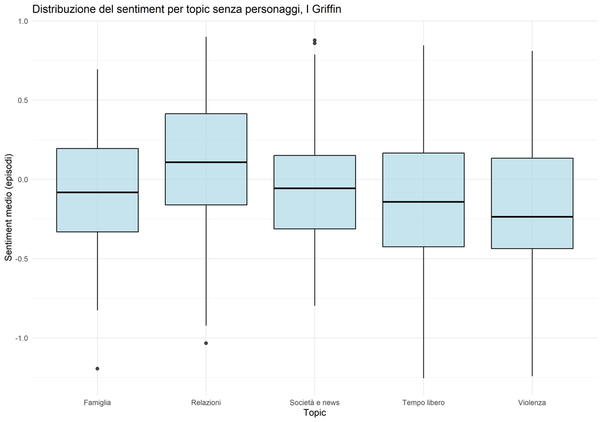

```r
ggplot(sentiment_lda_imdb_g, aes(x = factor(titolo_topic), y = sentiment)) +
  geom_boxplot(fill = "lightblue", color = "black", alpha = 0.7) +
  labs(
    title = "Distribuzione del sentiment per topic senza personaggi, I Griffin",
    x = "Topic",
    y = "Sentiment medio (episodi)"
  ) +
  theme_minimal()
```

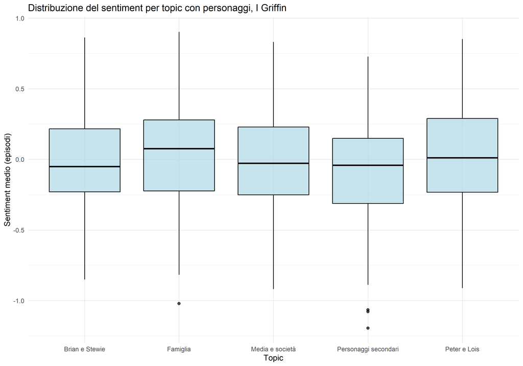

```r
ggplot(sentiment_lda_imdb_g2, aes(x = factor(titolo_topic), y = sentiment)) +
  geom_boxplot(fill = "lightblue", color = "black", alpha = 0.7) +
  labs(
    title = "Distribuzione del sentiment per topic con personaggi, I Griffin",
    x = "Topic",
    y = "Sentiment medio (episodi)"
  ) +
  theme_minimal()
```

Questo grafico mostra l’evoluzione del *sentiment* per diversi topic ne *I Griffin* attraverso le stagioni della serie. In generale, sembra ci sia un *trend* leggermente decrescente del *sentiment* medio nelle prime cinque stagioni e poi un graduale aumento. Famiglia mostra un chiaro *trend* di miglioramento nel tempo, partendo da valori negativi nelle prime stagioni per diventare progressivamente più positivo. Questo suggerisce come la serie abbia sviluppato nel tempo una rappresentazione più affettuosa della famiglia Griffin. Anche Tempo libero presenta una tendenza generale crescente, successivamente alle prime stagioni. Violenza presenta il *pattern* più interessante e meno conforme alle aspettative, iniziando con valori negativi, raggiungendo un picco molto negativo intorno alla stagione 5 (probabilmente il periodo più controverso della serie), per poi risalire verso valori neutri nelle stagioni successive. L’evoluzione suggerisce una maturazione della serie nel tempo. *I Griffin* sembrano aver sviluppato una rappresentazione più positiva dei rapporti familiari e interpersonali, moderando invece gli aspetti più controversi legati alla violenza. Questo potrebbe riflettere sia un’evoluzione creativa che una risposta alle critiche ricevute nelle stagioni centrali della serie. La versione senza personaggi non presenta differenze apprezzabili nei *trend*.

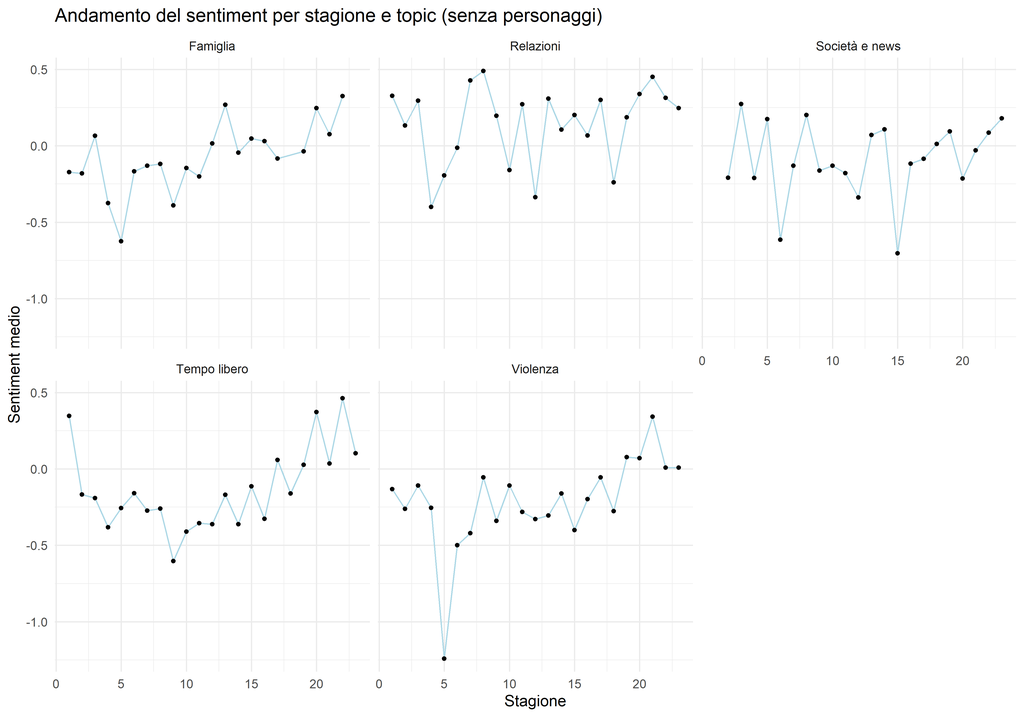

```r
sentiment_lda_imdb_g %>%
  group_by(titolo_topic, stagione) %>%
  summarise(sentiment_medio = mean(sentiment), .groups = "drop") %>%
  ggplot(aes(x = stagione, y = sentiment_medio)) +
  geom_line(color = "lightblue", size = 0.5) +
  geom_point(size = 1) +
  facet_wrap(~ titolo_topic, ncol = 3) +
  labs(
    title = "Andamento del sentiment per stagione e topic (senza personaggi)",
    x = "Stagione",
    y = "Sentiment medio"
  ) +
  theme_minimal()
```

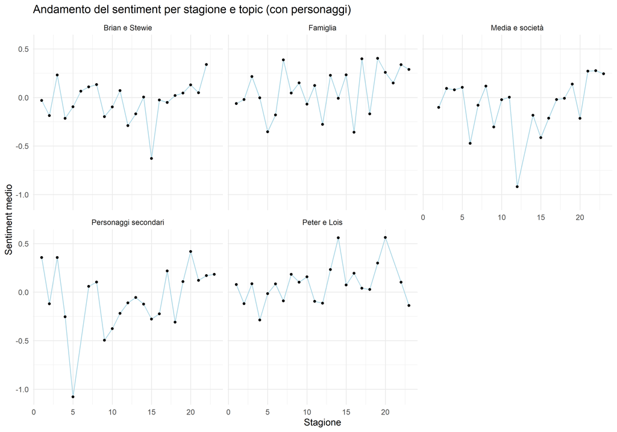

```r
sentiment_lda_imdb_g2 %>%
  group_by(titolo_topic, stagione) %>%
  summarise(sentiment_medio = mean(sentiment), .groups = "drop") %>%
  ggplot(aes(x = stagione, y = sentiment_medio)) +
  geom_line(color = "lightblue", size = 0.5) +
  geom_point(size = 1) +
  facet_wrap(~ titolo_topic, ncol = 3) +
  labs(
    title = "Andamento del sentiment per stagione e topic (con personaggi)",
    x = "Stagione",
    y = "Sentiment medio"
  ) +
  theme_minimal()
```

Si confrontano in seguito i *topic* comuni presenti ne *I Simpson* e *I Griffin*, nei grafici degli andamenti la prima stagione de *I Griffin* è allineata alla 14° stagione de *I Simpson* per sincronizzare temporalmente le due serie.

```r
titoli_topic_s <- c( "Fede e morte",
 "Amore e relazioni",
 "Amicizia e tempo libero",
 "Episodi natalizi",
 "Famiglia",
 "Scuola",
 "Lavoro e denaro")

titoli_topic_s2 <- c("Conversazioni",
                     "Lisa e scuola",
                     "Homer e Marge",
                     "Bart",
                     "Televisione e intrattenimento",
                     "Homer e lavoro",
                     "Homer e tempo libero")

titoli_topic_g <- c("Famiglia",
                    "Società e news",
                    "Relazioni",
                    "Tempo libero",
                    "Violenza")

titoli_topic_g2 <- c("Personaggi secondari",
                     "Peter e Lois",
                     "Famiglia",
                     "Media e società",
                     "Brian e Stewie")
```

Il confronto tra *I Simpson* (S) e *I Griffin* (G) sul topic “Famiglia” rivela forti differenze nella trattazione del tema familiare nelle due serie. *I Simpson* mostrano una distribuzione del *sentiment* familiare nettamente più positiva, con mediana sopra lo zero e quartili prevalentemente positivi, mentre *I Griffin* presentano una distribuzione più negativa, più orientata verso valori negativi. Nel grafico di destra *I Simpson* mantengono un andamento relativamente stabile nel tempo, ad eccezione di alcuni picchi negativi nelle ultime stagioni; *I Griffin* presentano valori molto negativi nelle prime stagioni per poi mostrare un carattere crescente, raggiungendo e superando *I Simpson* nelle stagioni più recenti. Le due serie mostrano andamenti concordi in diversi momenti. *I Simpson* hanno sempre mantenuto un approccio fondamentalmente affettuoso verso la famiglia, nonostante la satira. *I Griffin* hanno iniziato con una rappresentazione molto più cinica e disfunzionale dell’ambito familiare, ma si sono moderati nel tempo.

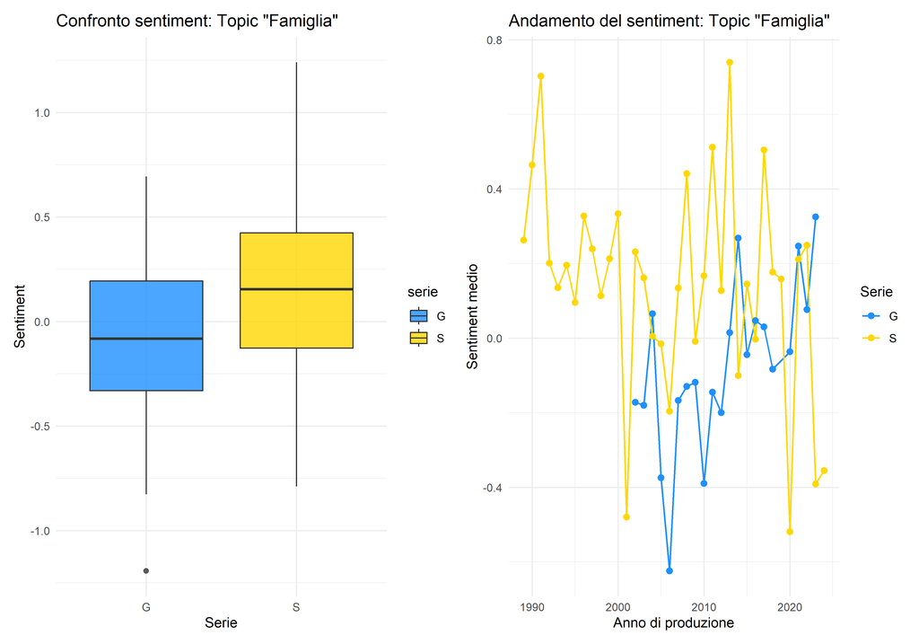

```r
library(patchwork)
# Confronto tra Simpson (topic 5) e Griffin (topic 1) per il topic "Famiglia"
# Boxplot della distribuzione del sentiment per il topic "Famiglia" in ciascuna serie
b1 <- ggplot(
  bind_rows(
    sentiment_lda_imdb_s %>% filter(topic == 5),           # Simpson: topic 5
    sentiment_lda_imdb_g %>% filter(topic == 1)            # Griffin: topic 1
  ),
  aes(x = serie, y = sentiment, fill = serie)              # Estetiche: serie sull'asse x, sentiment sull'asse y
) +
  geom_boxplot(alpha = 0.8) +                               # Boxplot con leggero effetto trasparenza
  labs(
    title = "Confronto sentiment: Topic \"Famiglia\"",
    x = "Serie",
    y = "Sentiment"
  ) +
  scale_fill_manual(values = c("S" = "#FFD700", "G" = "#1E90FF")) +     # Colori personalizzati: giallo per S, blu per G
  theme_minimal()                                           # Tema grafico pulito e minimal

# Grafico dell'andamento del sentiment medio per stagione
a1 <- bind_rows(
  sentiment_lda_imdb_s %>% filter(topic == 5) %>%
    mutate(stagione = stagione + 1988),             # Simpson: topic 5
  sentiment_lda_imdb_g %>%
    filter(topic == 1) %>%
    mutate(stagione = stagione + 13 + 1988)           # Griffin: si trasla la stagione in avanti di 13
) %>%
  group_by(serie, stagione) %>%                            # Si aggregano i dati per serie e stagione
  summarise(
    sentiment_medio = mean(sentiment, na.rm = TRUE),       # Si calcola il sentiment medio
    .groups = "drop"
  ) %>%
  ggplot(
    aes(x = stagione, y = sentiment_medio, color = factor(serie), group = serie)
  ) +
  geom_line(size = 0.6) +                                  # Linea per il trend stagionale
  geom_point(size = 2) +                                   # Punti per evidenziare ogni stagione
  labs(
    title = "Andamento del sentiment: Topic \"Famiglia\"",
    x = "Anno di produzione",
    y = "Sentiment medio",
    color = "Serie"
  ) +
  scale_color_manual(values = c("S" = "#FFD700", "G" = "#1E90FF")) +  # Colori coerenti col boxplot
  theme_minimal()

# Visualizzazione combinata: affianca boxplot e linea temporale
b1 + a1 + plot_layout(ncol = 2)                            # Disposizione orizzontale (2 colonne)
```

Il *topic* analizzato ora è quello della Coppia, mantenendo l’analisi con i personaggi per focalizzarsi sulle due coppie principali delle serie: Homer e Marge e Peter e Lois. *I Simpson* presentano una distribuzione più positiva per le relazioni di coppia, con mediana chiaramente sopra lo zero e quartili prevalentemente positivi. *I Griffin* mostrano una distribuzione centrata intorno allo zero, suggerendo un approccio più variegato e meno consistentemente positivo. Entrambe hanno una forte variabilità. *I Simpson* mostrano valori di *sentiment* generalmente positivi con diversi picchi, ma senza evidenza di un *trend* temporale stabile. L’andamento appare piuttosto variabile tra le stagioni, segnalando una rappresentazione della relazione con toni talvolta positivi, talvolta neutri, probabilmente legata a episodi dal contenuto emotivo disomogeneo. Al contrario, ne *I Griffin* il *sentiment* riferito alla coppia Peter e Lois presenta un andamento più definito: cresce progressivamente nelle stagioni centrali, suggerendo una raffigurazione crescentemente positiva del rapporto, seguita da un netto calo nelle ultime due stagioni, che potrebbe riflettere un maggior sarcasmo o conflittualità nella rappresentazione della coppia. *I Simpson* hanno tradizionalmente rappresentato Homer e Marge come una coppia solida nonostante i problemi, mentre *I Griffin* hanno oscillato tra rappresentazioni molto ciniche e momenti più romantici di Peter e Lois. Il calo de *I Simpson* nelle stagioni centrali potrebbe riflettere un periodo di maggiore focus sui conflitti matrimoniali nella serie. Nel complesso, l’andamento delle due serie sembra avere una correlazione positiva: nelle stagioni in cui il *sentiment* per una delle due coppie cresce, tende a farlo anche l’altra. Questo parallelismo potrebbe riflettere un’evoluzione simile nella scrittura dei personaggi coniugali o un’influenza reciproca tra le due serie nell’elaborazione della dimensione familiare e affettiva, forse anche influenzata dal contesto sociale del periodo in cui sono scritte le diverse stagioni.

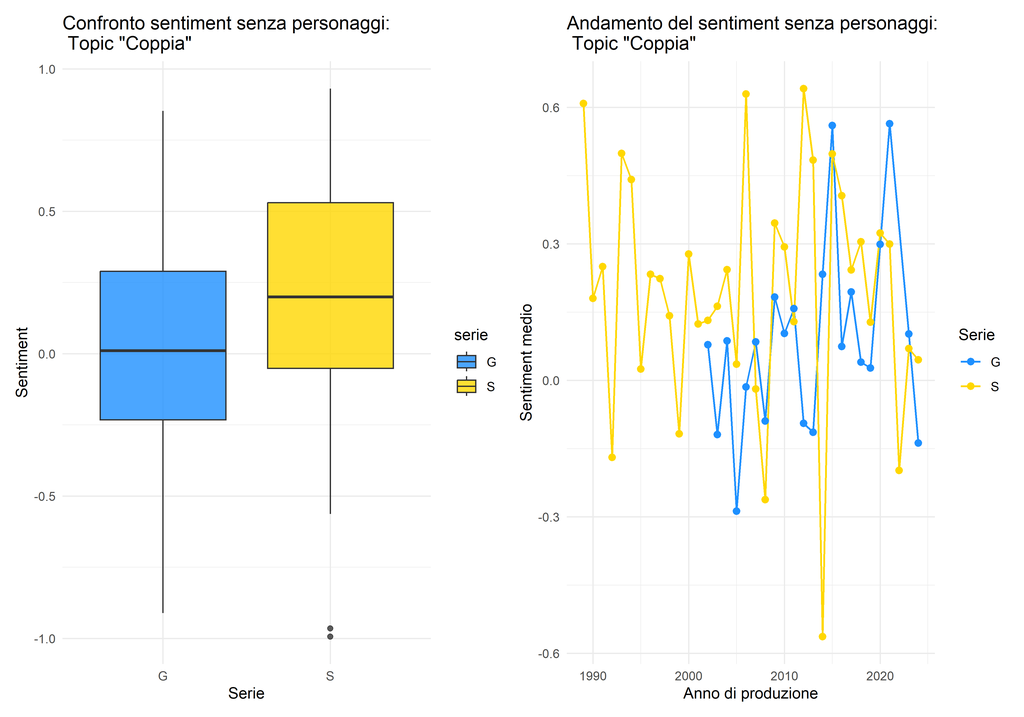

```r
# Homer e Marge vs Peter e Lois - confronto sentimenti su coppia (con personaggi)
# Topic 3 nei Simpson (dataset 2) e topic 2 nei Griffin (dataset 2)

# Boxplot: confronto distribuzione del sentiment tra Simpson e Griffin per il topic "Coppia" ---
b1 <- ggplot(
  bind_rows(
    sentiment_lda_imdb_s2 %>% filter(topic == 3),        # Simpson dataset 2, topic 3: relazione di coppia
    sentiment_lda_imdb_g2 %>% filter(topic == 2)         # Griffin dataset 2, topic 2: relazione di coppia
  ),
  aes(x = serie, y = sentiment, fill = serie)            # Serie (S o G) sull'asse x, sentiment sull'asse y, colore per serie
) +
  geom_boxplot(alpha = 0.8) +                             # Boxplot con trasparenza leggera (alpha = 0.8)
  labs(
    title = "Confronto sentiment senza personaggi: \n Topic \"Coppia\"",  # Titolo del grafico
    x = "Serie",                                           # Etichetta asse x
    y = "Sentiment"                                        # Etichetta asse y
  ) +
  scale_fill_manual(values = c("S" = "#FFD700", "G" = "#1E90FF")) +  # Colori: giallo per Simpson, blu per Griffin
  theme_minimal()                                          # Tema grafico pulito

# Andamento del sentiment medio nel tempo per ciascuna serie ---
a1 <- bind_rows(
  sentiment_lda_imdb_s2 %>% filter(topic == 3) %>%
    mutate(stagione = stagione + 1988),           # Topic "coppia" Simpson (dataset 2)
  sentiment_lda_imdb_g2 %>% filter(topic == 2) %>%
    mutate(stagione = stagione + 13 + 1988)                      # Per allineare stagioni Griffin dopo le 13 dei Simpson
) %>%
  group_by(serie, stagione) %>%
  summarise(
    sentiment_medio = mean(sentiment, na.rm = TRUE),      # Calcolo del sentiment medio per stagione e serie
    .groups = "drop"
  ) %>%
  ggplot(
    aes(x = stagione, y = sentiment_medio, color = factor(serie), group = serie)
  ) +
  geom_line(size = 0.6) +                                  # Linea che collega i punti nel tempo
  geom_point(size = 2) +                                   # Punti singoli per ciascun valore medio
  labs(
    title = "Andamento del sentiment senza personaggi: \n Topic \"Coppia\"",  # Titolo grafico
    x = "Anno di produzione",                                        # Etichetta asse x
    y = "Sentiment medio",                                 # Etichetta asse y
    color = "Serie"                                        # Etichetta legenda
  ) +
  scale_color_manual(values = c("S" = "#FFD700", "G" = "#1E90FF")) +  # Colori coerenti: Simpson oro, Griffin blu
  theme_minimal()                                          # Tema grafico semplice

# Unione dei due grafici in una sola visualizzazione affiancata ---
b1 + a1 + plot_layout(ncol = 2)                            # Layout con 2 colonne: boxplot a sinistra, line plot a destra
```

Il grafico confronta il *sentiment* espresso nei commenti riguardanti i personaggi nel mondo reale delle due serie, inclusi principalmente nel *topic* riguardante il mondo dello spettacolo. Il *boxplot* mostra la distribuzione del *sentiment* complessivo: la distribuzione del *sentiment* nelle due serie resta analogo ai *topic* precedenti, con valori per *I Simpson* maggiormente positivi che per *I Griffin*. In particolare, *I Griffin* mostrano maggiore variabilità e oscillazioni più forti, con *sentiment* medio spesso negativo, soprattutto tra le stagioni centrali, che riflettono lo stile della serie: una narrazione spesso irriverente, provocatoria e senza filtri.

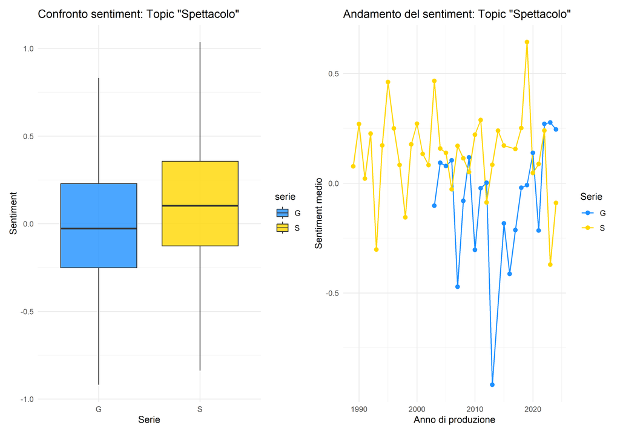

```r
# Creazione del boxplot per confrontare la distribuzione del sentiment
# tra Simpson (topic 2) e Griffin (topic 4) sul tema "Spettacolo/personaggi pubblici"
b1 <- ggplot(
  bind_rows(
    sentiment_lda_imdb_s2 %>% filter(topic == 2),         # Filtra i dati dei Simpson per il topic 2
    sentiment_lda_imdb_g2 %>% filter(topic == 4)          # Filtra i dati dei Griffin per il topic 4
  ),
  aes(x = serie, y = sentiment, fill = serie)             # Estetiche: serie sull'asse x, sentiment sull'asse y
) +
  geom_boxplot(alpha = 0.8) +                              # Aggiunge boxplot con trasparenza all'80%
  labs(
    title = "Confronto sentiment: Topic \"Spettacolo\"",  # Titolo del grafico
    x = "Serie",                                           # Etichetta asse x
    y = "Sentiment"                                        # Etichetta asse y
  ) +
  scale_fill_manual(values = c("S" = "#FFD700", "G" = "#1E90FF")) +    # Colori personalizzati: giallo per Simpson, blu per Griffin
  theme_minimal()                                          # Tema grafico minimalista

# Creazione del line plot per mostrare l'evoluzione del sentiment medio nel tempo
a1 <- bind_rows(
  sentiment_lda_imdb_s2 %>% filter(topic == 2) %>%
    mutate(stagione = stagione + 1988),           # Seleziona i Simpson topic 2
  sentiment_lda_imdb_g2 %>%
    filter(topic == 4) %>%
    mutate(stagione = stagione + 13 + 1988)                      # Aggiunge 13 per allineare le stagioni di Griffin
) %>%
  group_by(serie, stagione) %>%                            # Raggruppa per serie e stagione
  summarise(sentiment_medio = mean(sentiment, na.rm = TRUE), .groups = "drop") %>%  # Calcola la media del sentiment
  ggplot(
    aes(x = stagione, y = sentiment_medio, color = factor(serie), group = serie)    # Estetiche per il grafico a linee
  ) +
  geom_line(size = 0.6) +                                  # Aggiunge linea del trend
  geom_point(size = 2) +                                   # Aggiunge punti sulle medie per ogni stagione
  labs(
    title = "Andamento del sentiment: Topic \"Spettacolo\"",  # Titolo del grafico
    x = "Anno di produzione",                                        # Etichetta asse x
    y = "Sentiment medio",                                 # Etichetta asse y
    color = "Serie"                                        # Legenda
  ) +
  scale_color_manual(values = c("S" = "#FFD700", "G" = "#1E90FF")) +  # Colori: giallo Simpson, blu Griffin
  theme_minimal()                                          # Tema grafico pulito

# Combina i due grafici (boxplot + lineplot) affiancandoli su una riga
b1 + a1 + plot_layout(ncol = 2)                            # Disposizione dei grafici in 2 colonne
```

Di seguito, si analizzano i topic relativi ai personaggi più giovani delle due serie. I *boxplot* sulla distribuzione del *sentiment* suggeriscono che gli *script* con protagonisti come Stewie e Brian tendano a essere più pungenti, riflessivi o cinici, mentre quelli centrati su Bart siano più leggeri o spensierati. Ne *I Simpson* si nota una tendenza stabile, generalmente positiva, con alcuni picchi verso l’alto. Ne *I Griffin*, invece, si mostrano ampie oscillazioni da positivo a fortemente negativo lungo le stagioni, con le stagioni centrali contenenti picchi molto negativi. Bart Simpson è un personaggio adolescenziale, dispettoso ma fondamentalmente innocente: gli *script* si affidano all’ironia, al ruolo ribelle ma non drastico, da cui sembra derivare un *sentiment* più equilibrato. Stewie (genio malvagio in miniatura) e Brian (cane parlante, saggio ma cinico) rappresentano personalità più complesse: battute taglienti, riflessioni adulte, satira sociale e istanti esistenziali.

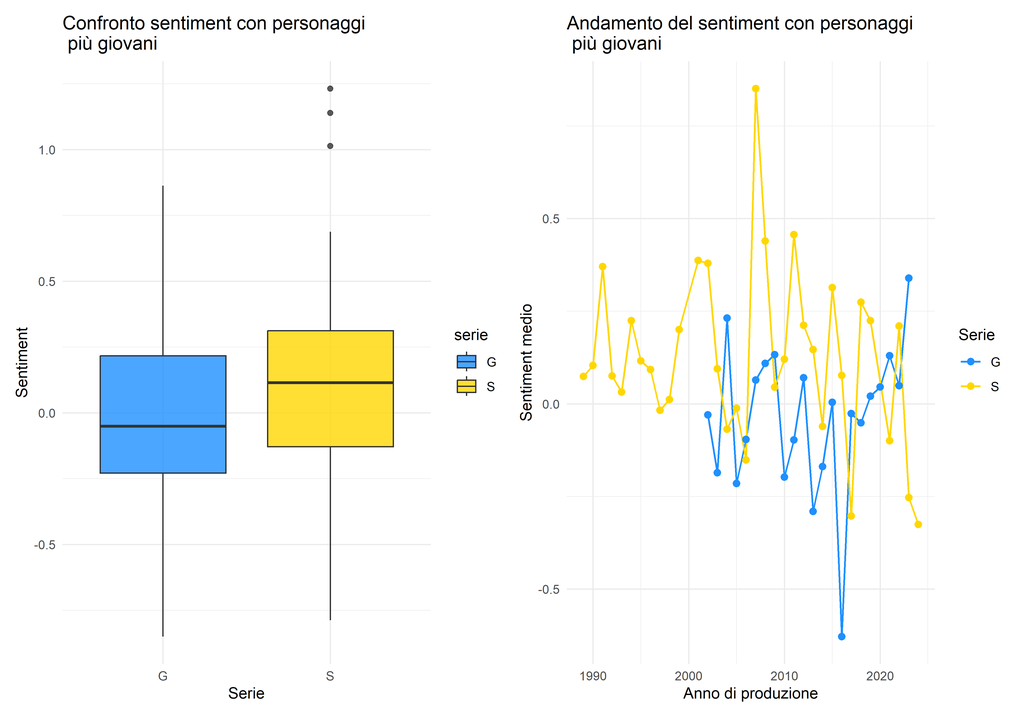

```r
# Bart vs Brian e Stewie: Simpson topic 4, Griffin topic 5

# Confronto distribuzione del sentiment tra Simpson (Bart) e Griffin (Brian & Stewie)
b1 <- ggplot(
  bind_rows(
    sentiment_lda_imdb_s2 %>% filter(topic == 4),       # Filtra topic 4 dei Simpson (riguardante Bart)
    sentiment_lda_imdb_g2 %>% filter(topic == 5)        # Filtra topic 5 dei Griffin (Brian e Stewie)
  ),
  aes(x = serie, y = sentiment, fill = serie)           # Mappa serie sull'asse x, sentiment sull'asse y e colore per serie
) +
  geom_boxplot(alpha = 0.8) +                            # Aggiunge boxplot con trasparenza per visualizzare la distribuzione
  labs(
    title = "Confronto sentiment con personaggi \n più giovani",  # Titolo del grafico
    x = "Serie",                                          # Etichetta asse x
    y = "Sentiment"                                       # Etichetta asse y
  ) +
  scale_fill_manual(values = c("S" = "#FFD700", "G" = "#1E90FF")) +  # Colori personalizzati: giallo (Simpson), blu (Griffin)
  theme_minimal()                                        # Tema grafico minimale e pulito

# Evoluzione temporale del sentiment medio per ciascuna serie
a1 <- bind_rows(
  sentiment_lda_imdb_s2 %>% filter(topic == 4) %>%
    mutate(stagione = stagione + 1988),         # Filtra i dati dei Simpson (topic 4)
  sentiment_lda_imdb_g2 %>%
    filter(topic == 5) %>%
    mutate(stagione = stagione + 13 + 1988)                    # Aggiunge 13 alle stagioni dei Griffin per allinearle a quelle dei Simpson
) %>%
  group_by(serie, stagione) %>%                         # Raggruppa per serie e stagione
  summarise(
    sentiment_medio = mean(sentiment, na.rm = TRUE),    # Calcola il sentiment medio per gruppo
    .groups = "drop"                                     # Rimuove la struttura di grouping dopo il summarise
  ) %>%
  ggplot(
    aes(x = stagione, y = sentiment_medio, color = factor(serie), group = serie)  # Definisce le estetiche
  ) +
  geom_line(size = 0.6) +                                # Aggiunge linee per mostrare l’andamento nel tempo
  geom_point(size = 2) +                                 # Aggiunge punti per ogni media calcolata
  labs(
    title = "Andamento del sentiment con personaggi \n più giovani",  # Titolo del grafico
    x = "Anno di produzione",                                      # Etichetta asse x
    y = "Sentiment medio",                               # Etichetta asse y
    color = "Serie"                                      # Titolo della legenda
  ) +
  scale_color_manual(values = c("S" = "#FFD700", "G" = "#1E90FF")) +  # Colori coerenti con il boxplot
  theme_minimal()                                        # Tema minimale per coerenza stilistica

# Combinazione dei due grafici affiancati (boxplot + lineplot)
b1 + a1 + plot_layout(ncol = 2)                          # Dispone i due grafici su due colonne (affiancati)
```

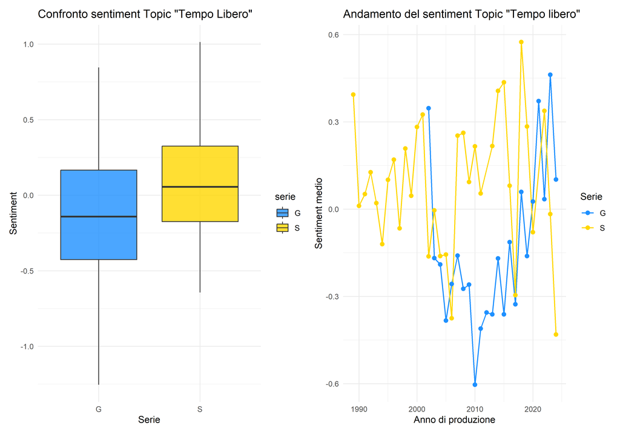

```r
# Tempo libero: Simpson topic 7 e Griffin topic 4
# Confronto tra le serie per il topic legato al tempo libero
b1 <- ggplot(
  bind_rows(
    sentiment_lda_imdb_s %>% filter(topic == 7),       # Filtra i dati dei Simpson (versione 1) per il topic 7 (tempo libero)
    sentiment_lda_imdb_g %>% filter(topic == 4)        # Filtra i dati dei Griffin per il topic 4 (tempo libero)
  ),
  aes(x = serie, y = sentiment, fill = serie)          # Mappa: serie sull’asse x, sentiment sull’asse y, colore in base alla serie
) +
  geom_boxplot(alpha = 0.8) +                           # Boxplot con trasparenza per rendere le box più leggibili
  labs(
    title = "Confronto sentiment Topic \"Tempo Libero\"",  # Titolo del grafico
    x = "Serie",                                        # Etichetta asse x
    y = "Sentiment"                                     # Etichetta asse y
  ) +
  scale_fill_manual(values = c("S" = "#FFD700", "G" = "#1E90FF")) +  # Colori personalizzati: giallo (Simpson), blu (Griffin)
  theme_minimal()                                      # Tema grafico minimale e pulito

# Andamento temporale del sentiment medio per il topic "Tempo libero"
a1 <- bind_rows(
  sentiment_lda_imdb_s %>% filter(topic == 7) %>%
    mutate(stagione = stagione + 1988),         # Filtra i dati dei Simpson (versione 1) per topic 7
  sentiment_lda_imdb_g %>%
    filter(topic == 4) %>%
    mutate(stagione = stagione + 13 + 1988)                   # Aggiusta le stagioni dei Griffin sommando 13 per allinearle a quelle dei Simpson
) %>%
  group_by(serie, stagione) %>%                        # Raggruppa i dati per serie e stagione
  summarise(
    sentiment_medio = mean(sentiment, na.rm = TRUE),   # Calcola la media del sentiment per ogni gruppo
    .groups = "drop"                                    # Elimina il grouping dopo il summarise
  ) %>%
  ggplot(
    aes(x = stagione, y = sentiment_medio, color = factor(serie), group = serie)  # Definisce le mappature per il grafico
  ) +
  geom_line(size = 0.6) +                              # Aggiunge una linea continua per mostrare l’evoluzione nel tempo
  geom_point(size = 2) +                               # Aggiunge i punti per ogni valore medio calcolato
  labs(
    title = "Andamento del sentiment Topic \"Tempo libero\"",  # Titolo del grafico
    x = "Anno di produzione",                                    # Etichetta asse x
    y = "Sentiment medio",                             # Etichetta asse y
    color = "Serie"                                    # Titolo della legenda
  ) +
  scale_color_manual(values = c("S" = "#FFD700", "G" = "#1E90FF")) +  # Colori coerenti col boxplot
  theme_minimal()                                     # Tema minimale per uno stile pulito

# Unisce i due grafici (boxplot + lineplot) affiancati su due colonne
b1 + a1 + plot_layout(ncol = 2)
```

## Correlazioni con *rating* IMDb

Si è voluto infine indagare, con metodi solo esplorativi, l’andamento del *rating* rilevato da IMDb al variare dei risultati ottenuti precedentemente.

```r
rat_s = imdb$rating[imdb$serie == 'S']
rat_g = imdb$rating[imdb$serie == 'G']
sea_s = imdb$stagione[imdb$serie == 'S']
sea_g = imdb$stagione[imdb$serie == 'G']
```

Il primo grafico mostra la distribuzione del *rating* di entrambe le serie. Non risultano differenze rilevanti, se si tiene presente la maggior numerosità degli episodi de *I Simpson*, che portano a gonfiare la “pancia” del *boxplot*.

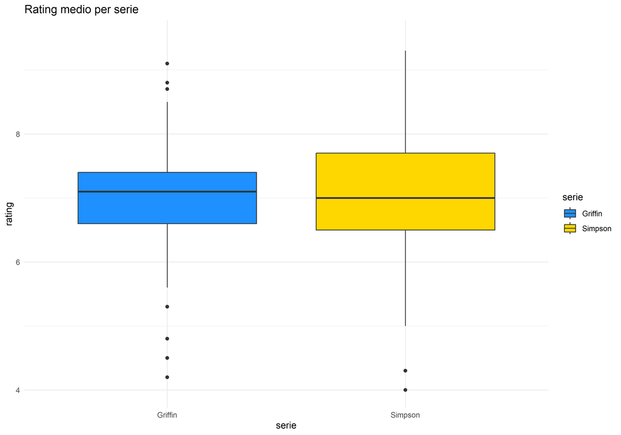

```r
# Subset dei dati
simpson <- imdb %>% filter(serie == "S") %>% mutate(serie = "Simpson")
griffin  <- imdb %>% filter(serie == "G") %>% mutate(serie = "Griffin")

# Dati unificati per boxplot
dati_boxplot <- bind_rows(simpson, griffin)

g1 <- ggplot(dati_boxplot, aes(x = serie, y = rating, fill = serie)) +
  geom_boxplot() +
  scale_fill_manual(values = c("Simpson" = "#FFD700", "Griffin" = "#1E90FF")) +
  ylim(4, 9.5) +
  labs(title = "Rating medio per serie") +
  theme_minimal()
g1
```

Il secondo grafico è un’analisi bivariata tra *rating* e stagione delle serie. Il *rating* de *I Simpson* cresce nelle prime 7 stagioni per poi diminuire gradualmente. Ne *I Griffin* l’andamento è decrescente, con meno variabilità rispetto a *I Simpson*. In generale, si osserva un fenomeno piuttosto frequente: le recensioni del pubblico sono tendenzialmente decrescenti al proseguire delle stagioni.

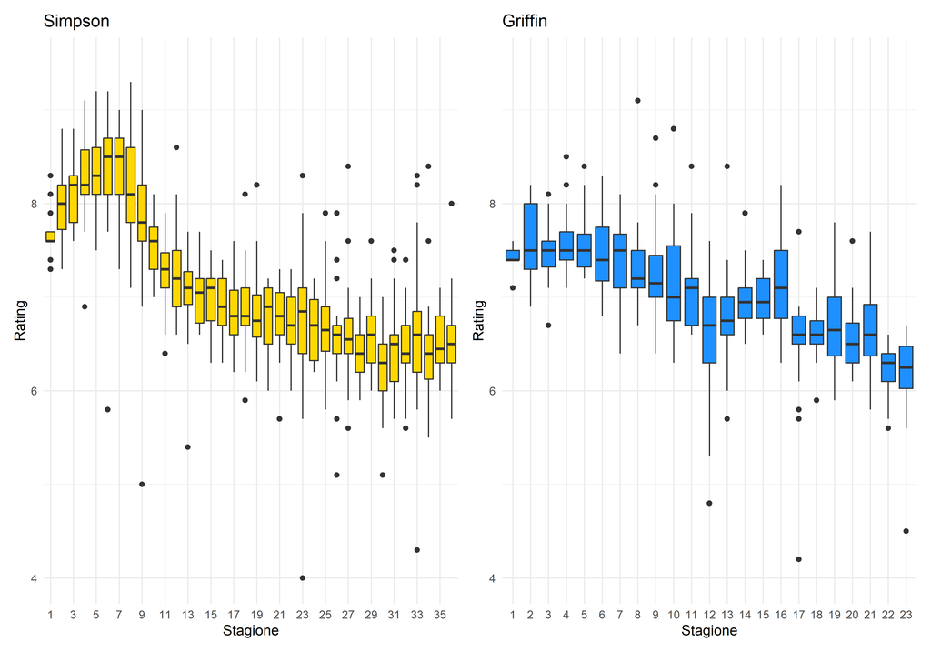

```r
stagioni_simpson <- levels(factor(simpson$stagione))
stagioni_mostrati <- stagioni_simpson[as.numeric(stagioni_simpson) %% 2 == 1]  # dispari

g2 <- ggplot(simpson, aes(x = factor(stagione), y = rating)) +
  geom_boxplot(fill = "#FFD700") +
  ylim(4, 9.5) +
  labs(title = "Simpson", x = "Stagione", y = "Rating") +
  scale_x_discrete(breaks = stagioni_mostrati) +
  theme_minimal()

g3 <- ggplot(griffin, aes(x = factor(stagione), y = rating)) +
  geom_boxplot(fill = "#1E90FF") +
  ylim(4, 9.5) +
  labs(title = "Griffin", x = "Stagione", y = "Rating") +
  theme_minimal()
g2 + g3
```

Il terzo grafico illustra l’analisi bivariata tra *rating* e *sentiment*. Curiosamente, non sembra esserci correlazione tra le due variabili, né per *I Simpson* né per *I Griffin*.

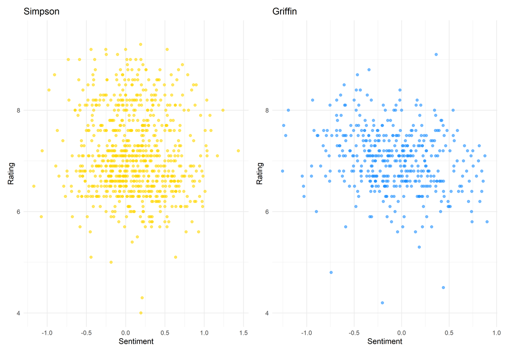

```r
g4 <- ggplot(sentiment_per_episode_s, aes(x = sentiment, y = rat_s)) +
  geom_point(color = "#FFD700", alpha = 0.6) +
  ylim(4, 9.5) +
  labs(title = "Simpson", x = "Sentiment", y = "Rating") +
  theme_minimal()

g5 <- ggplot(sentiment_per_episode_g, aes(x = sentiment, y = rat_g)) +
  geom_point(color = "#1E90FF", alpha = 0.6) +
  ylim(4, 9.5) +
  labs(title = "Griffin", x = "Sentiment", y = "Rating") +
  theme_minimal()
g4 + g5
```

## Conclusioni

Nel presente progetto si è condotta un’analisi comparativa approfondita delle serie animate *I Simpson* e *I Griffin*, utilizzando tecniche di text mining, topic modeling e sentiment analysis sui dialoghi degli episodi. I risultati ottenuti confermano empiricamente molte delle differenze percepite tra le due serie e rivelano interessanti dinamiche evolutive nel corso del tempo.

#### Differenze Linguistiche e Stilistiche

L’analisi delle frequenze e della *keyness* hanno evidenziato chiaramente le differenze linguistiche tra le due serie. *I Griffin* si caratterizzano per un linguaggio significativamente più provocatorio, trasgressivo e colorito, con termini come “*hell*” e “*damn*” che ricorrono con frequenza molto superiore rispetto a *I Simpson*. Al contrario, *I Simpson* mantengono un registro più neutro e accessibile, coerente con il loro target familiare più ampio.

L’analisi degli n-grammi ha rivelato in entrambe le serie una forte presenza di dialoghi in prima persona, caratteristica tipica delle *sitcom* familiari, ma con tonalità differenti: *I Griffin* mostrano espressioni più emotive ed enfatiche (quali “w*hat the hell*”, “*oh my god*”), mentre *I Simpson* prediligono un linguaggio più quotidiano e moderato.

#### Evoluzione Temporale dei Personaggi

L’analisi longitudinale ha rivelato significativi cambiamenti nell’importanza relativa dei personaggi principali. Ne *I Simpson*, si osserva chiaramente il passaggio da Bart come protagonista iniziale a Homer come figura centrale, confermando quanto dichiarato dal creatore Matt Groening. In *I Griffin*, Peter mantiene una posizione dominante costante, mentre personaggi come Stewie mostrano un crescente rilievo nelle stagioni più recenti.

#### Topic Modeling e Tematiche Ricorrenti

L’applicazione della *Latent Dirichlet Allocation* ha identificato 9 macro-temi comuni alle due serie: Vita familiare, Relazioni sentimentali, Intrattenimento e media, Festività natalizie, Eventi anomali, Ambiente scolastico, Lavoro e denaro, Matrimonio e Politica e attualità. Tuttavia, la trattazione di questi temi differisce sostanzialmente tra le serie, con *I Griffin* che adottano approcci più cinici e provocatori.

L’analisi STM (*Structural Topic Modeling*) ha rivelato interessanti effetti temporali non lineari, suggerendo che l’evoluzione delle serie sia influenzata da fattori complessi che vanno oltre il semplice progredire degli anni. Tra questi fattori, sembra difficile distinguere tra quelli esogeni, relativi al contesto socio-culturale o alle reazioni del pubblico, e quelli endogeni, dovuti ai cambiamenti dei produttori o di altri soggetti nella produzione.

#### Sentiment Analysis e Caratterizzazione Emotiva

La *Sentiment Analysis* ha confermato quantitativamente le differenze di tono percepite tra le serie. *I Simpson* mantengono un sentiment mediamente più positivo e stabile nel tempo, con le prime stagioni caratterizzate da valori relativamente alti. *I Griffin* presentano invece forti oscillazioni e valori generalmente più bassi, riflettendo il loro carattere più controverso.

Particolarmente significativo è l’andamento del sentiment sul tema Famiglia: mentre *I Simpson* mantengono un approccio costantemente affettuoso nonostante la satira, *I Griffin* mostrano un’evoluzione da rappresentazioni inizialmente molto ciniche verso toni progressivamente più positivi nelle stagioni recenti, suggerendo una maturazione della serie nel tempo.

#### Riflessioni Metodologiche

L’approccio multidisciplinare adottato, combinando tecniche di *Text Mining*, *Topic Modeling* e *Sentiment Analysis*, si è rivelato efficace nell’identificare *pattern* nascosti nei testi. Tuttavia, l’analisi ha evidenziato alcuni limiti metodologici, in particolare nella ricerca delle associazioni tra termini, dove la granularità a livello di episodio si è rivelata troppo ampia, richiedendo una segmentazione del testo in finestre più piccole.

#### Considerazioni Finali

Questo studio dimostra come l’analisi quantitativa dei testi possa fornire evidenze empiriche a supporto di percezioni qualitative consolidate. *I Simpson* e *I Griffin*, pur condividendo *format* e alcuni temi ricorrenti, si distinguono nettamente per approccio linguistico, trattamento tematico e evoluzione temporale.

*I Simpson* emergono come una serie più stabile e *family-friendly*, capace di mantenere un equilibrio tra satira sociale e valori familiari positivi. *I Griffin* si caratterizzano invece per un approccio più sperimentale e provocatorio, con una minore variabilità tematica e lessicale, ma allo stesso tempo un’evoluzione del tono più marcata nel corso del tempo. Un’estensione metodologica del presente lavoro potrebbe consistere in un’indagine approfondita sull’origine dell’eterogeneità tra le due serie a livello intra-episodico, al fine di valutare se i risultati rilevati siano attribuibili a strutture ricorrenti presenti a una scala più fine rispetto a quella sinora esaminata.

I risultati ottenuti aprono interessanti prospettive per future ricerche, sia nell’approfondimento dell’analisi comparativa di prodotti mediali simili, sia nell’applicazione di tecniche di analisi testuale più sofisticate per catturare sfumature semantiche e narrative più sottili. L’integrazione di metadati esterni (come i riassunti IMDb) si è rivelata particolarmente utile per la validazione e interpretazione dei risultati del *Topic Modeling*, suggerendo direzioni promettenti per analisi future più complete e contestualizzate.